# ESM204_a4_Art_Berkovitz

Kristin Art and Simone Berkovitz

2023-05-23

```r
knitr::opts_chunk$set(echo = TRUE, warning = FALSE, message = FALSE, results = FALSE)
library(here)
library(tidyverse)
library(janitor)
library(dplyr)
library(purrr)
library(kableExtra)
library(ggforce)
library(cowplot)
library(patchwork)
```

### Calculating the social cost of carbon and policy choice under uncertainty

In this exercise, we used modeled estimates of future damages caused by global warming to derive the social cost of carbon (SCC), investigated how discounting influences its calculation, and assessed how uncertainty influences climate policy choices.

```r
#load in data
damages_raw = read_csv(here("a4/damages.csv"))
warming_raw = read_csv(here("a4/warming.csv"))
```

## Question 1

First, we estimated and plotted a quadratic damage function relating the dollar value of damages to the change in global mean temperature based on the modeled data (Figure 1). We omitted an intercept term since there should be no damages by construction when there is no climate change.

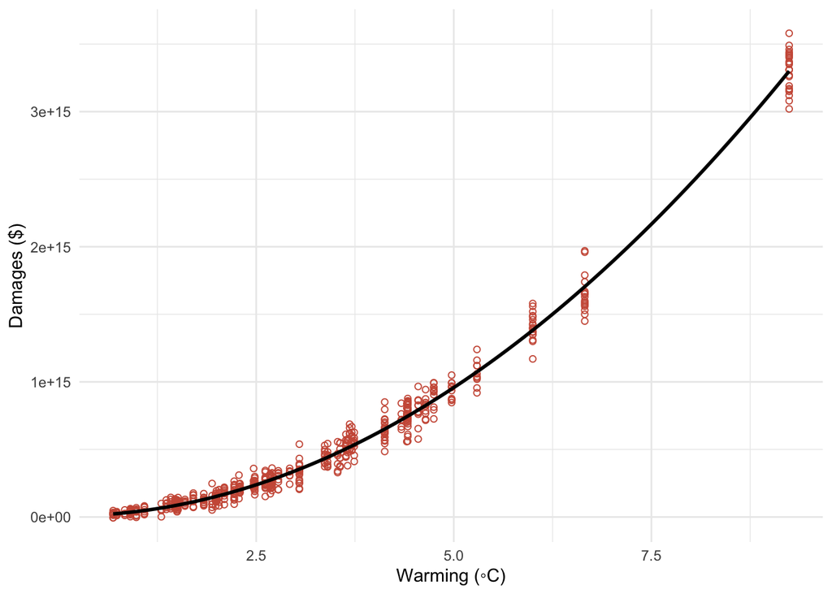

**Figure 1:** Estimated annual total damages from climate change at different levels of global mean temperature warming.

```r
#exploratory plot
plot_0 = ggplot(damages_raw, aes(x = warming, y = damages)) +
  geom_point(shape = 1, color = 'coral3')+
  labs(x = "Warming (◦C)", y = "Damages ($)")+
  theme_minimal()

#plot_0

#add a warming squared value to df
damages_df = damages_raw %>%
  mutate(warming2 = (warming)^2)

#fit a quadratic regression model to damages data
qm = lm(damages ~ 0 + warming + warming2, data = damages_df)
summary(qm)

#add qm to plot using geom_smooth (option 1)
plot_1 = plot_0 +
  geom_smooth(method = "lm", formula = y ~ x + I(x^2), se = FALSE, color = 'black')

plot_1
```

```r
#add qm to plot using predicted values (option 2)
#create sample data to visualize model
warming_samples = as.numeric(seq(from = 0, to = 10))
damages_predict = as.numeric(predict(qm, list(warming = warming_samples, warming2 = warming_samples^2)))

#combine into one df
damage_predictions_df = cbind(warming_samples, damages_predict) %>%
  as.data.frame()

#add to plot
plot_1 = plot_0 +
  geom_line(data = damage_predictions_df, aes(x = warming_samples, y = damages_predict))

#plot_1
```

The estimated quadratic damage function is
$$y(x) = 0 + -2.05e{12}*x + 3.88e{13}*x^2$$
where

- *y* is estimated annual total damages ($) and
- *x* is global mean temperature warming (◦C)

## Question 2

Next, we used the estimated damage function to predict total damages in each year under two climate trajectories. The climate trajectories include a “baseline” future climate warming trajectory (in ◦C relative to the pre-industrial period) and a “pulse” trajectory that includes a one-time pulse of 35 billion tons of CO2 to the atmosphere today. Estimated annual damages in each trajectory are shown in Figure 2 alongside the difference in damages between the two scenarios over time and per ton of CO2 (Figure 2).

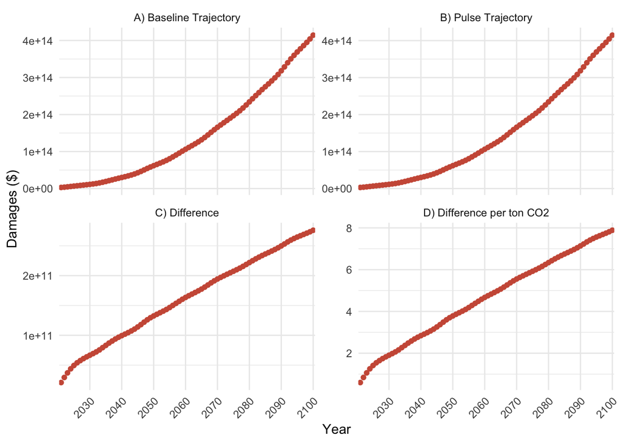

```r
#define function for damages based on qm
compute_damages = function(warming){
  #damage = 0 + a*warming + b*warming^2
  damage = 0 + (qm$coefficients['warming'])*warming + (qm$coefficients['warming2'])*(warming^2)

  return(damage)
}

#apply damages function and calculate the things
warming_df = warming_raw %>%
  mutate(est_damage_bl = purrr::map_dbl(.x = warming_baseline, .f = compute_damages), #compute damages for baseline scenario
         est_damage_p = purrr::map_dbl(.x = warming_pulse, .f = compute_damages), #compute damages for pulse scenario
         diff_damages = est_damage_p - est_damage_bl, #compute difference between above two
         diff_per_ton = diff_damages/35000000000, #compute difference per ton
         year = as.factor(year), #make year a factor for plotting
         t = as.numeric(seq(0, 79, 1))) #add column for timestep

 #pivot longer
warming_df_longer = warming_df %>%
  select(-c(warming_baseline, warming_pulse)) %>% #remove columns we don't need
  pivot_longer(cols = "est_damage_bl":"diff_per_ton", names_to = "variable", values_to = "damage") %>%
  mutate(across(variable, factor, levels = c("est_damage_bl", "est_damage_p", "diff_damages", "diff_per_ton"))) #make variable column a factor with levels to control order of subplots below

#plot estimates
plot_2 = ggplot(warming_df_longer, aes(x = year)) +
  geom_point(aes(y = damage), color = "coral3") +
  facet_wrap(~ variable, scales = "free_y", nrow = 2, labeller = as_labeller(c(est_damage_bl = 'A) Baseline Trajectory', est_damage_p='B) Pulse Trajectory', diff_damages = "C) Difference", diff_per_ton ='D) Difference per ton CO2'))) +
  labs(x = "Year", y = "Damages ($)") +
  theme_minimal()+
  scale_x_discrete(breaks = seq(2020,2100,10))+
  theme(axis.text.x = element_text(angle = 45, hjust = 1))

plot_2
```

## Question 3

Here, we investigated how discounting influences the calculation of SCC, which is defined as the present discounted value of the stream of future damages caused by one additional ton of CO2. We calculated SCC between 2021-2100 (total of 79 years) for discount rates between 1-8% using the following formula:

$$\sum_{t = 0}^{79}\frac{damage_t}{(1 +
r)^t}$$
Results indicate that higher discount rates result in lower SCC values (Figure 3).

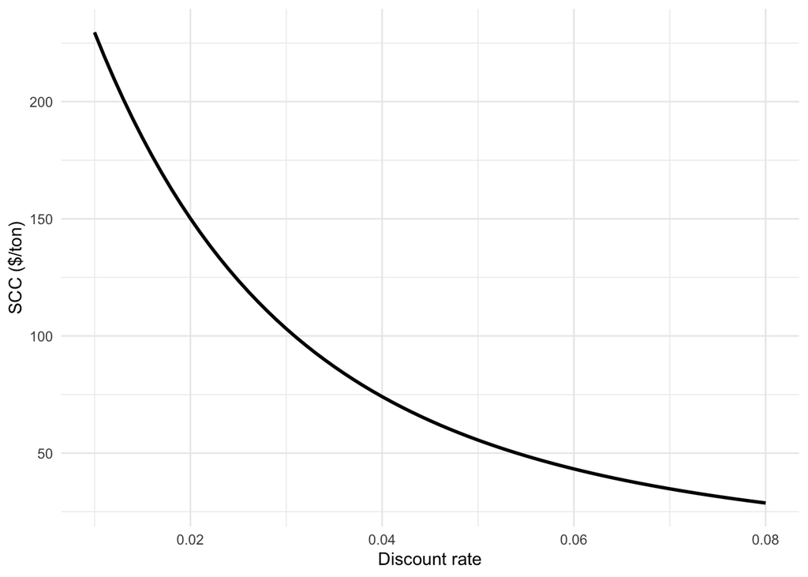

**Figure 3:** Estimated social cost of carbon (SCC) as a function of discount rate.

```r
#define function to calculate generic PV
calculate_PV = function(range, damages, r){
  #initialize total value
  total = 0

  #run for loop over specified range to calculate PV with discount
  for (i in range){
    total = total + damages[warming_df$t == i]/(1 + r)^i
  }
  return(total)
}

#define discount rates
r = seq(from = 0.01, to = 0.08, by = 0.001)

#apply function to discount rates
SCC = map(.x = r, damages = warming_df$diff_per_ton, range = warming_df$t, .f = calculate_PV) %>%
  unlist() %>%
  as.data.frame() %>%
  rename("SCC" = 1)

SCC_results = cbind(r, SCC)

#plot results
plot_3 = ggplot(SCC_results, aes(x = r, y = SCC))+
  geom_line(size = 1)+
  labs(x = "Discount rate", y = "SCC ($/ton)")+
  theme_minimal()

plot_3
```

## Question 4

Next, we calculated the SCC based on the Ramsey Rule, which the National Academies of Sciences, Engineering, and Medicine advised the government to use in 2017 when discounting within the SCC calculation. The Ramsey Rule is as follows:
$$r = ρ +
ηg$$
where:

- η is the elasticity of marginal utility of consumption with respect to income
- δ is the pure rate of time preference
- g is the growth rate of income over time

In this exercise, we calculate the discount rate with the following values:
$$ρ = 0.001$$
$$η = 2$$
$$g =
0.01$$

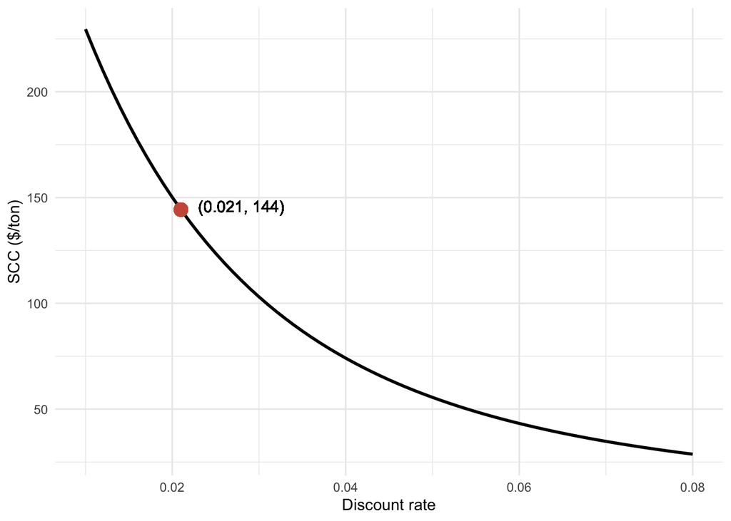

**Figure 4:** Estimated social cost of carbon (SCC) as a function of discount rate. Red dot represents the discount rate and SCC calculated by the Ramsey Rule, which was recommended by the National Academies of Sciences, Engineering, and Medicine.

```r
#define variables
q = 0.001
n = 2
g = 0.01

#calculate discount rate and resulting SCC
rr = as.numeric((q + n*g))
rr_SCC = as.numeric(calculate_PV(rr, damages = warming_df$diff_per_ton, range = warming_df$t))

#add to plot
plot_4 = plot_3 +
  geom_point(aes(x = rr, y = rr_SCC), color = 'coral3', size = 4) +
  geom_text(aes(x = rr, y = rr_SCC), label = "(0.021, 144)", hjust = -0.2, vjust = 0.2)

plot_4
```

The discount rate calculated by the Ramsey Rule is 2.1% and the resulting SCC value is $144, which is shown in Figure 4.

## Question 5

Lastly, we analyzed two possible climate policies that could be pursued with a discount rate of 2%.

```r
#define discount rate of 2%
r = 0.02

#add more columns to warming_df
warming_df = warming_df %>%
  mutate(warming_1.5bl = as.numeric(1.5*warming_baseline), #compute 1.5 times baseline warming
         est_damage_1.5bl = as.numeric(compute_damages(warming_1.5bl)), #compute damages for 1.5 times baseline
         year = as.numeric(as.character(year)), #convert year from factor to numeric
         warming_polB = (case_when(year < 2050 ~ warming_baseline, year >= 2050 ~ 1.29)), #compute warming for policy B scenario
         est_damage_polB = as.numeric(compute_damages(warming_polB)), #compute damages for policy B scenario
         t2 = as.numeric(t - 29))

#define policy A variables
p = 0.5
c = 0

#define function to calculate expected present value under policy A
compute_EPV_A = function(r, p, c){
  #calculate the total cost of baseline scenario
  total_bl = as.numeric(calculate_PV(r = r, damages = warming_df$est_damage_bl, range = warming_df$t))

  #calculate the total cost of 1.5 times baseline scenario
  total_1.5 = as.numeric(calculate_PV(r = r, damages = warming_df$est_damage_1.5bl, range = warming_df$t))

  #add total benefits, subtract total costs, and multiply by probability
  EPV_A = (total_bl + total_1.5 - c)*p
  return(EPV_A)
}

EPV_A = compute_EPV_A(r = r, c = c, p = p)
EPV_A

#policy B: take immediate and strong action against climate change
#define policy B variables
p = 1
c = 0

compute_EPV_B = function(r, c, p){

  #calculate the total cost of policy B scenario
  total_polB = as.numeric(calculate_PV(r = r, damages = warming_df$est_damage_polB, range = warming_df$t))

  #add total benefits, subtract total costs and multiply by probability
  EPV_B = (total_polB - c)*p

  return(EPV_B)
}

#cost of implementation is not included yet
EPV_B = compute_EPV_B(r = r, c = c, p = p)
EPV_B

#calculate difference in damages
EPV_diff = EPV_B - EPV_A
EPV_diff

#now include implementation cost of Policy B as a check
c = EPV_diff
EPV_B2 = compute_EPV_B(r = r, c = c, p = p)
EPV_B2 = abs(EPV_B2)

#check that EPV_B with implementation cost included is equal to EPV_A with implementation cost included
round(EPV_B2) == round(EPV_A) #yes, true
```

```r
#show results in table
EPV_results = cbind(EPV_A, EPV_B) %>%
  as.data.frame()

table_1 = kable(EPV_results, format = "markdown", caption = "Table 1: Expected Present Value of damages up to 2100 under Policy A and Policy B.")

table_1
```

Table 1: Expected Present Value of damages up to 2100 under Policy A and Policy B.

| EPV_A | EPV_B |
| --- | --- |
| 6.191008e+15 | 1.588654e+15 |

We calculated the expected present value of damages up to 2100 under both policies to determine which would be result in fewer total damages (Table 1). The expected present value (EPV) of damages up to 2100 under Policy A is $6,191,007,989,790,814 while the expected present value (EPV) of damages up to 2100 under Policy B is $1,588,654,059,747,278. If society is risk-neutral, Policy B could cost up to $-4,602,353,930,043,536 to implement and still make economic sense to pursue over Policy A if Policy A cost $0 to implement.

If society were risk averse, Policy B would be more attractive because the outcome and potential losses are certain due to the 100% probability. In Policy A however, the outcome is uncertain. There is a 50% chance warming will follow the baseline and result in lower damages, but there’s also a 50% risk that warming will be 1.5 times higher than the baseline and cause more damages.